# Practical Machine Learning Peer Graded Assignment

Chiara Mondino

2 oktober 2016

## Background

Using devices such as Jawbone Up, Nike FuelBand, and Fitbit it is now possible to collect a large amount of data about personal activity relatively inexpensively. These type of devices are part of the quantified self movement - a group of enthusiasts who take measurements about themselves regularly to improve their health, to find patterns in their behavior, or because they are tech geeks. One thing that people regularly do is quantify how much of a particular activity they do, but they rarely quantify how well they do it. In this project, your goal will be to use data from accelerometers on the belt, forearm, arm, and dumbell of 6 participants. They were asked to perform barbell lifts correctly and incorrectly in 5 different ways.

The goal of this project is to predict the manner in which they did the exercise. This is the `classe` variable in the training set, considering any of the other variables as predictors.

## How the model was built

The outcome variable is the `classe`, a factor variable of `5` levels:

- A - exactly according to the specification
- B - throwing the elbows to the front
- C - lifting the dumbbell only halfway
- D - lowering the dumbbell only halfway
- E - throwing the hips to the front

Models evaluation will be based on maximising the accuracy and minimazing the out of sample error. We will build two different models, using decision tree and random forests methods. The model with the highest accuracy will be choosen as the final Model and will be validated on the original testing data set.

## Cross Validation

We will subset the training set into two subsamples:

- subtraing data set, as `70%` of the original training data set
- testing data set, as `30%` of the original training data set We will fit the model using the subtesting data set and test it on the testing data set. Once the best model is choosed, it will be validated on the original testing data set

## Expected out of sample error

The expected out of sample error will correpond to the *accuracy* in the cross-validation data. Accuracy is the proportion between the correctly classified observation over the total observation in the subtraining set used for testing the model. Expected Accurracy is the accuracy in the out of sample data set, i.e. the original testing data set. The *expected out of sample error* will then correspond to the proportion between the missclassified observation over the total observation in the original testing data set.

## Necessary Packages and Set Seed

The following packages are required:

```r
suppressMessages(library(caret))
suppressMessages(library(randomForest))
suppressMessages(library(rpart))
suppressMessages(library(rpart.plot))
suppressMessages(library(RColorBrewer))
suppressMessages(library(rattle))
suppressMessages(library(ggplot2))
```

In order to ensure reproducibility of the analysis, we will set the seed to 1000

```r
set.seed(1000)
```

## Getting and Cleaning the data

Download the training and the testing data set from the provided web link:

```r
##training data set
trainUrl <- "http://d396qusza40orc.cloudfront.net/predmachlearn/pml-training.csv"
##testing data set
testUrl <- "http://d396qusza40orc.cloudfront.net/predmachlearn/pml-testing.csv"

##load the training data
training <- read.csv(url(trainUrl), na.strings=c("NA","#DIV/0!",""))
##load the testing data
testing <- read.csv(url(testUrl), na.strings=c("NA","#DIV/0!",""))
```

First, we split the training data set into two subsamples, the `70%` will be used as training set and the remaining `30%` will be used as testing set.

```r
inTrain <- createDataPartition(training$classe, p = 0.7, list = FALSE)
subTraining <- training[inTrain, ]
subTesting <- training[-inTrain, ]
dim(subTraining)
```

```
## [1] 13737   160
```

```r
dim(subTesting)
```

```
## [1] 5885  160
```

We perform data cleaning in multiple steps, listed below.

We will remove the first `7` columns as they are metadata and not relevant for the prediction

```r
subTraining <- subTraining[, -c(1:7)]
```

We will then clean the data set from all variables with high number of NAs and with variance close to 0.

```r
##clean near zero variance variables
NearZeroVar <- nearZeroVar(subTraining, saveMetrics = TRUE)
subTraining <- subTraining[, NearZeroVar$nzv == FALSE]
```

Finally, we remove all variables that have more than `60%` of `NA` values

```r
subTraining_clean <- subTraining
for (i in 1:length(subTraining)){
    if(sum(is.na(subTraining[, i]))/ nrow(subTraining) >= .6) {
        for (j in 1:length(subTraining_clean)){
            if(length(grep(names(subTraining[i]), names(subTraining_clean)[j])) == 1){
                subTraining_clean <- subTraining_clean[, -j]
            }
        }
    }
}

subTraining <- subTraining_clean
```

Let’s now apply the same transformation to the subTesting and Tesing data set

```r
##clean the subtesting data set
clean1 <- colnames(subTraining)
subTesting <- subTesting[clean1]

##clean the testing data set (already with column Classe removed)
clean2 <- colnames(subTraining[, -53])
testing <- testing[clean2]
```

## Model with Random Forests

We will build a random forests model on the subtraining data set and the validate it on the subtesting data set (`30%` of the original training data set).

All other variables are used to predict variable `Classe`.

```r
##create the model with randomForest function
modFit_rf <- randomForest(classe ~., data = subTraining)

##calculate predicted values
pred_rf <- predict(modFit_rf, subTesting)

##calculate confusion matrix
cm_rf <- confusionMatrix(pred_rf, subTesting$classe)
print(cm_rf)
```

```
## Confusion Matrix and Statistics
##
##           Reference
## Prediction    A    B    C    D    E
##          A 1671    5    0    0    0
##          B    3 1133    6    0    0
##          C    0    1 1018   10    0
##          D    0    0    2  953    3
##          E    0    0    0    1 1079
##
## Overall Statistics
##
##                Accuracy : 0.9947
##                  95% CI : (0.9925, 0.9964)
##     No Information Rate : 0.2845
##     P-Value [Acc > NIR] : < 2.2e-16
##
##                   Kappa : 0.9933
##  Mcnemar's Test P-Value : NA
##
## Statistics by Class:
##
##                      Class: A Class: B Class: C Class: D Class: E
## Sensitivity            0.9982   0.9947   0.9922   0.9886   0.9972
## Specificity            0.9988   0.9981   0.9977   0.9990   0.9998
## Pos Pred Value         0.9970   0.9921   0.9893   0.9948   0.9991
## Neg Pred Value         0.9993   0.9987   0.9984   0.9978   0.9994
## Prevalence             0.2845   0.1935   0.1743   0.1638   0.1839
## Detection Rate         0.2839   0.1925   0.1730   0.1619   0.1833
## Detection Prevalence   0.2848   0.1941   0.1749   0.1628   0.1835
## Balanced Accuracy      0.9985   0.9964   0.9950   0.9938   0.9985
```

Accuracy of the model is `99%`, which means the expected out of sample error is `1%`. Let’s check the error rate for all the different trees evaluated by the model

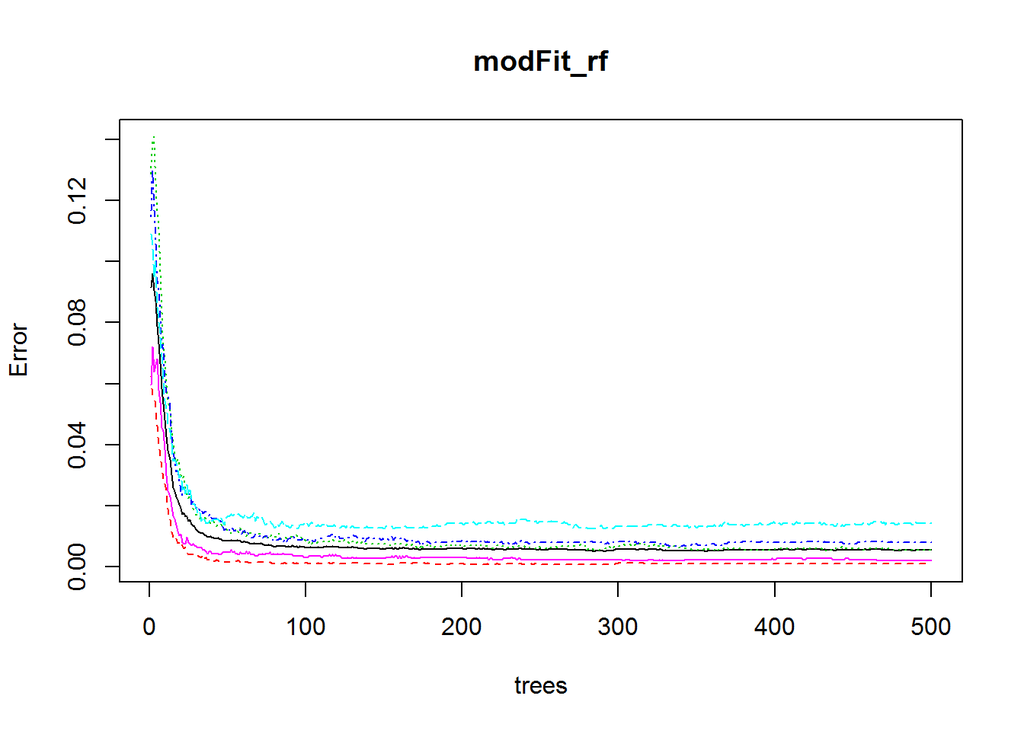

```r
plot(modFit_rf)
```

Error rate is always below `14%` for all the `500` trees.

## Model with Decision Tree

```r
modFit_dt <- rpart(classe ~., data = subTraining, method = "class")

##calculate predicted values
pred_dt <- predict(modFit_dt, subTesting, type = "class")

##calculate the confusion matrix
cm_dt <- confusionMatrix(pred_dt, subTesting$classe)
print(cm_dt)
```

```
## Confusion Matrix and Statistics
##
##           Reference
## Prediction    A    B    C    D    E
##          A 1461  150   10   57   50
##          B   88  814  138   68   71
##          C   14  111  790  161   83
##          D   44   56   47  643   82
##          E   67    8   41   35  796
##
## Overall Statistics
##
##                Accuracy : 0.7653
##                  95% CI : (0.7543, 0.7761)
##     No Information Rate : 0.2845
##     P-Value [Acc > NIR] : < 2.2e-16
##
##                   Kappa : 0.7028
##  Mcnemar's Test P-Value : < 2.2e-16
##
## Statistics by Class:
##
##                      Class: A Class: B Class: C Class: D Class: E
## Sensitivity            0.8728   0.7147   0.7700   0.6670   0.7357
## Specificity            0.9366   0.9231   0.9241   0.9535   0.9686
## Pos Pred Value         0.8455   0.6904   0.6816   0.7374   0.8405
## Neg Pred Value         0.9488   0.9309   0.9501   0.9360   0.9421
## Prevalence             0.2845   0.1935   0.1743   0.1638   0.1839
## Detection Rate         0.2483   0.1383   0.1342   0.1093   0.1353
## Detection Prevalence   0.2936   0.2003   0.1969   0.1482   0.1609
## Balanced Accuracy      0.9047   0.8189   0.8470   0.8102   0.8521
```

## Final Prediction

Considering the higher accuracy of the model built using the randon forests method, we will use the first model to predict on the testing data

```r
finalPred <- predict(modFit_rf, testing, type = "class")
print(finalPred)
```

```
##  1  2  3  4  5  6  7  8  9 10 11 12 13 14 15 16 17 18 19 20
##  B  A  B  A  A  E  D  B  A  A  B  C  B  A  E  E  A  B  B  B
## Levels: A B C D E
```

## Conclustion

We have choosed to compare two different machine learning algoritms which are well known for their ability of detecting the features that are important for classification: Random Forest and Decison Tree.

Based on the data we had, the Random Forest algorithm proved to be more accurate to predict the quality level of the exercise execution.